# Erosive disturbance

[NO_SLIT_004] (forests)

Author

Affiliation

Joachim Töpper

Norwegian Institute for Nature Research

Published

June 6, 2026

Reviewed by

Matthew Grainger

**TipMetadata**

Table 1: Indicator metadata

| Variable | Value |
| --- | --- |
| Indicator ID | NO_SLIT_004 |
| Indicator Name | Erosive disturbance |
| Country | Norway |
| Continent | Europe |
| Ecosystem Condition Typology Class | A1 - Physical characteristics |
| Realm | Terrestrial (T) |
| Biome | T2 Temperate-boreal forests and woodlands biome |
| Ecosystem | T2.1 Boreal/montane forests; T2.2 Deciduous temperate forests; T2.3 Oceanic temp rainforests |
| Year added | 2025 |
| Last update | 2026 |
| Version | 2.0.0 |
| Version comment | separate code for forest ecosystem. Updated variable combination matrix. |
| Normalised | TRUE |
| Spatial aggregation pathway | Scale/Truncate - Aggregate (zero-one inflated beta-regression) |

**TipLog**

- 21 May 2026 - original start-up of the 2026 erosion species indicator for forests

## 2. About the underlying data

Here, we evaluate the ‘Erosive disturbance’ indicator based on field sampled data from the Norwegian nature monitoring program ANO (Tingstad et al. 2019). In ANO, two relevant variables are registered for this indicator, ‘7_TK’ (erosion from heavy vehicles) and ‘7_SE’ (erosion from overuse).

### 2.1 Spatial and temporal resolution and extent

The ANO monitoring data available now represent one cycle of sampling from 2019-2024 comprising ca. 1000 sites across Norway. ANO has no defined end date. 2025 is the first year of repeated sampling for about 20% of the approximately 1000 ANO sites for all of mainland Norway (i.e. the Ecosystem Accounting Area). Annual sampling is spatially representative, in principle allowing to compute area-representative estimates for single years but also multiple-yr-reporting periods. The indicator at hand is calculated based on the ANO data from 2020-2024.

### 2.2 Sampling design

At every ANO site, the indicator variable is registered at up to 18 monitoring points, dependent on the ecosystem designation.

### 2.3 Original units

Data on erosive disturbance in both 7_TK and 7_SE in ANO are given on a coarse 4 step scale within a 250 m<sup>2</sup> sample circle, indicating how much area is affected by either heavy vehicle or overuse erosion, where 0 = 0 cover, 1 = 0-1/16 cover, 2 = 1/16-1/2 cover, and 3 = 1/2-1 cover.

### 2.4 Instructions for citing, using and accessing data

The ANO data are openly available at https://kartkatalog.miljodirektoratet.no/Dataset/Details/2054

### 2.5 Additional comments about the dataset

The ANO program is run by the Norwegian Environment Agency. On their web sites you may also find some additional summary data. https://www.miljodirektoratet.no/ansvarsomrader/overvaking-arealplanlegging/miljoovervaking/overvakingsprogrammer/natur-pa-land/arealrepresentativ-naturovervakning-ano/

## 3. Indicator properties

### 3.1 Ecosystem Condition Typology Class (ECT)

The ‘Erosive disturbance’ indicator reflects the physical environment and thus represents ECT class ‘A1 Physical characteristics’.

### 3.2 Ecosystem condition characteristic

The ‘Erosive disturbance’ indicator addresses both the ecosystem characteristics ‘primary productivity’ and ‘abiotic conditions’, in the Norwegian standard on ecological condition (Nybø and Evju, 2017).

### 3.3 Collinearities with other indicators

None.

### 3.4 Impact factors

The main impact factor for this indicator is human overuse of an area.

## 4. Reference condition and levels

### 4.2 Reference levels

X<sub>100</sub>: 0 share of the monitoring site area with erosive disturbance.

X<sub>60</sub>: less than 1/16th of the area in both the heavy vehicle (7_tk) and the overuse (7_se) variables.

X<sub>0</sub>: more than 1/2 of the area in either the heavy vehicle (7_tk) or the overuse (7_se) variables.

#### 4.2.1 Spatial resolution and validity

The same reference levels apply to all types of ecosystems and all regions.

## 5. Uncertainties

### 5.1 General uncertainties

A significant aforest of uncertainty stems From the coarse 4-level scale on which the data underlying this indicator are collected, where each category (other than 0) spans a differently large range of abundance. Uncertainties relate partly to sampling and observer variability (and possible observer bias) in the recording of the plant cover data. Spatial variability as a source of descriptive uncertainty can be quantified.

## 6. References

Nybø, S. & Evju, M. (red.) 2017. Fagsystem for fastsetting av god økologisk tilstand. Forslag fra et ekspertråd, https://regjeringen.no/no/dokument/rapportar-og-planar/id438817/.

Tingstad, L., Evju, M., Sickel, H., & Töpper, J. 2019. Utvikling av nasjonal arealrepresentativ naturovervåking (ANO). Forslag til gjennomføring, protokoller og kostnadsvurderinger med utgangspunkt i erfaringer fra uttesting i Trøndelag. NINA Rapport 1642.

## 7. Import and prepare datasets

### 7.1 ANO point data

Import ANO testing data: First, download from [Miljødirektoratet](https://nedlasting.miljodirektoratet.no/naturovervaking/naturovervaking_eksport.gdb.zip) then upload it from local storage.

```r
#Sys.setlocale("LC_ALL", "no_NB.utf8") #works with æøå or use "Norwegian"
ANO.geo <- st_read("P:/41201785_okologisk_tilstand_2022_2023/data/ANO/naturovervaking_eksport.gdb",
                   layer="ANO_SurveyPoint", quiet = T)
#head(ANO.geo)
```

## 8. Spatial units

The spatial units for the ‘Erosive disturbance’ indicator are governed by the ANO data, which consist of 1000 randomly chosen sites in Norway. Each site is a 500 x 500 m grid cell with 18 monitoring circles of 250sqm and a central 1 x 1 m vegetation plot. The basic unit for which observational data on erosive disturbance from heavy vehicles and overuse exist, and for which every the ‘Erosive disturbance’ indicator is computed, is the 250sqm circle. Aggregation of these basic spatial units to higher ones - like sites, municipalities, counties, regions, or the national level - should be done with appropriate consideration of the spatial structure of the data, i.e. imbalances and clustering (highly unequal number of points of an ecosystem type between sites).

## 9. Analyses

#### Data handling

First we need to do some data handling. The data for this evaluation need to represent forest ecosystems and the years 2020-2024.

```r
## fix NiN-variables
colnames(ANO.geo)
ANO.geo <- ANO.geo %>%
           rename("tungekjoretoy" = "bv_7tk",
           "slitasje" = "bv_7se")
colnames(ANO.geo)

# remove variable code in the data
ANO.geo$tungekjoretoy <- gsub("7TK_", "", ANO.geo$tungekjoretoy)
unique(ANO.geo$tungekjoretoy)
ANO.geo$tungekjoretoy <- gsub("X", "NA", ANO.geo$tungekjoretoy)
unique(ANO.geo$tungekjoretoy)
ANO.geo$tungekjoretoy <- as.numeric(ANO.geo$tungekjoretoy)
unique(ANO.geo$tungekjoretoy)

ANO.geo$slitasje <- gsub("7SE_", "", ANO.geo$slitasje)
unique(ANO.geo$slitasje)
ANO.geo$slitasje <- gsub("X", "NA", ANO.geo$slitasje)
unique(ANO.geo$slitasje)
ANO.geo$slitasje <- as.numeric(ANO.geo$slitasje)
unique(ANO.geo$slitasje)

## we create a new erosion-variable for the indicator based on both the tungekjoretoy- and slitasje-variables
# Thus, we combine two variables with scales 0-3. To be able to represent combined impact from both variables the new erosion variable will have a range of 0-4.
# First, we illustrate the two variables and the new levels representing the combination of the two variables in a matrix
matrix(
  data=c(0,1,2,3,1,1.5,2.75,3.5,2,2.75,3,3.75,3,3.5,3.75,4),
  nrow=4,ncol=4,
  dimnames = list(c("se_0","se_1","se_2","se_3"),c("tk_0","tk_1","tk_2","tk_3"))
  )
# we can see that this results in values on a scale from 0-4 representing all combinations of the heavy vehicles and overuse variables

# next we introduce the erosion variable to the dataframe
ANO.geo <- ANO.geo %>%
  mutate(erosion=case_when( (is.na(tungekjoretoy)|tungekjoretoy==0) & !is.na(slitasje) ~ slitasje,
                             (is.na(slitasje)|slitasje==0) & !is.na(tungekjoretoy) ~ tungekjoretoy,
                             tungekjoretoy==1 & slitasje==1 ~ 1.5,
                             tungekjoretoy==2 & slitasje==2 ~ 3,
                             tungekjoretoy==3 & slitasje==3 ~ 4,
                             tungekjoretoy==2 & slitasje==1 ~ 2.75,
                             tungekjoretoy==1 & slitasje==2 ~ 2.75,
                             tungekjoretoy==3 & slitasje==1 ~ 3.5,
                             tungekjoretoy==1 & slitasje==3 ~ 3.5,
                             tungekjoretoy==3 & slitasje==2 ~ 3.75,
                             tungekjoretoy==2 & slitasje==3 ~ 3.75
                             )
  )

## choose forest ecosystems and years 2020-2024.
ANO.forest <- ANO.geo %>%
  filter(hovedoekosystem_250m2 == 'skog') %>%
  filter(aar %in% 2020:2024)

#head(ANO.forest)



## check that every point is present only once
#length(levels(as.factor(ANO.forest$ano_flate_id)))
#length(levels(as.factor(ANO.forest$ano_punkt_id)))
#summary(as.factor(ANO.forest$ano_punkt_id))
# there's many double presences, probably some wrong registrations of point numbers,


## add region information
nor <- st_read(here::here("data/outlineOfNorway_EPSG25833.shp"),
               quiet = T)%>%
  st_as_sf() %>%
  st_transform(crs = st_crs(ANO.forest))

reg <- st_read(here::here("data/regions.shp"),
               quiet = T) %>%
  st_as_sf() %>%
  st_transform(crs = st_crs(ANO.forest))

# change region names to something R-friendly
# reg$region
reg$region <- c("Northern.Norway","Central.Norway","Eastern.Norway","Western.Norway","Southern.Norway")

regnor <- st_intersection(reg,nor)

ANO.forest = st_join(ANO.forest, regnor, left = TRUE, join = st_nearest_feature)
```

We can illustrate the erosion in ANO points in Norway’s five regions in three figures.

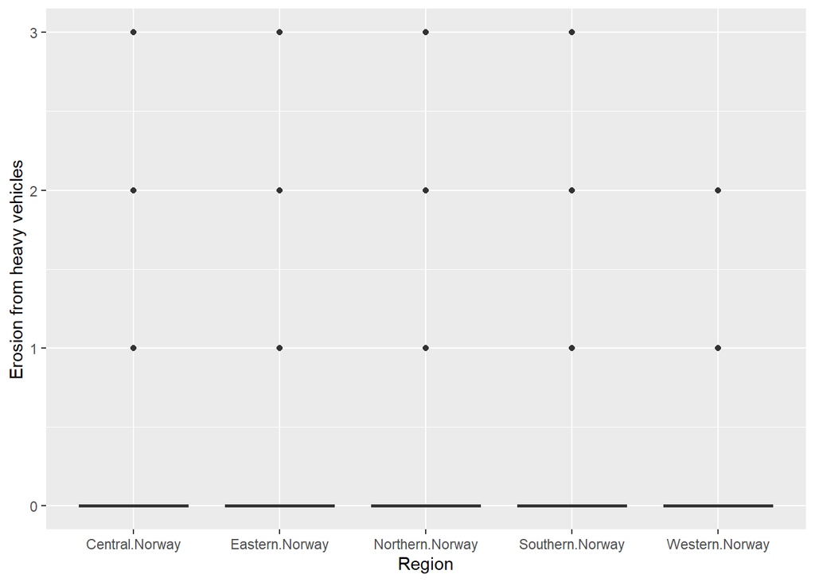

```r
ggplot(ANO.forest, aes(x = region, y = tungekjoretoy)) +
  geom_boxplot() +
  labs(
    x = "Region",
    y = "Erosion from heavy vehicles"
    )
```

[figure not shown]

```r
ggplot(ANO.forest, aes(x = region, y = slitasje)) +
  geom_boxplot() +
  labs(
    x = "Region",
    y = "Erosion from uveruse"
    )
```

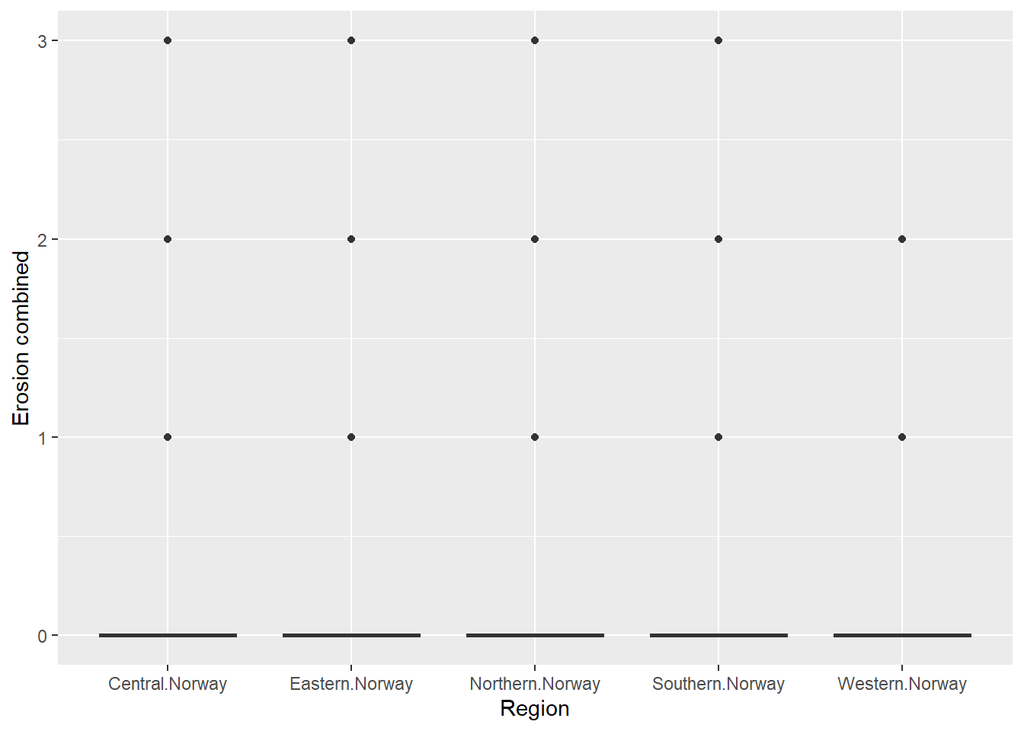

```r
ggplot(ANO.forest, aes(x = region, y = erosion)) +
  geom_boxplot() +
  labs(
    x = "Region",
    y = "Erosion combined"
    )
```

#### Normalisation

We use a normalisation function scaling linearly between the reference values. The function is demonstrated in the code below, and in Figure 1.

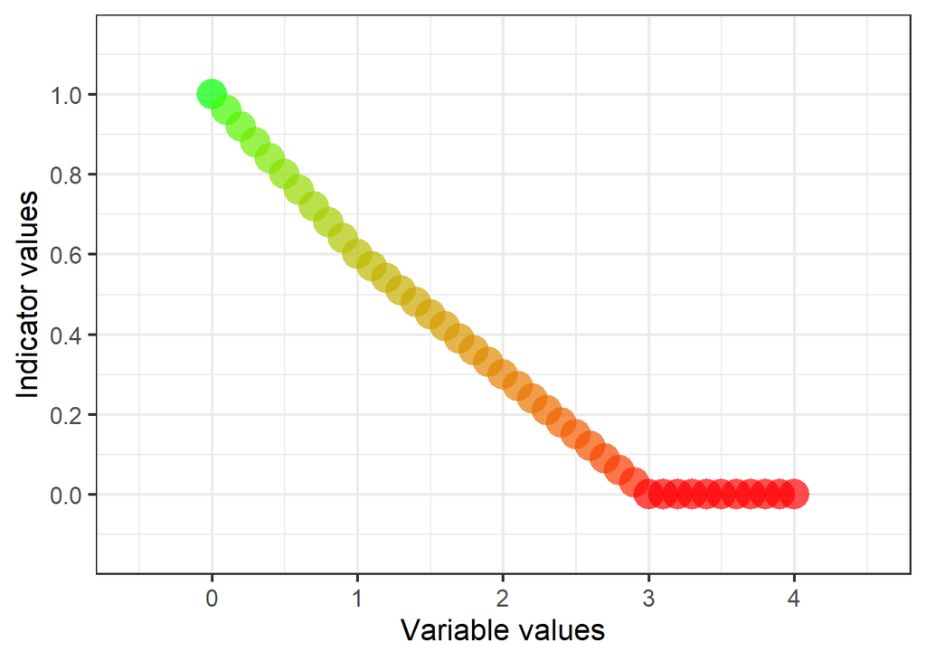

Figure 1: Normalisation function (piecewise linear)

```r
temp <- tibble(
  variable = seq(0,4,0.1)
)

temp <- temp %>% mutate(indicator = ec_normalise(variable = variable,
                          x0 = 3,
                          x60 = 1,
                          x100 = 0,
                          fun = "linear")
)

ec_norm_plot(temp$variable, temp$indicator)
```

We scale the variable values to indicator values using ec_normalise() from ecTools.

```r
ANO.forest <- ANO.forest %>% mutate(erosion_res = ec_normalise(variable = erosion,
                          x0 = 3,
                          x60 = 1,
                          x100 = 0,
                          fun = "linear")
)

summary(ANO.forest$erosion_res)
```

[output not shown]

## 10. Results

Indicator values are calculated as arithmetic means of the normalised indicator values. To quantify uncertainty, we perform a stratified cluster bootstrap with 1,000 replicates. Within each replicate, ANO sites are resampled with replacement within each region while retaining all monitoring points from each selected site. The distribution of bootstrap estimates is used to calculate the mean indicator value and the associated 95% confidence interval.

```r
set.seed(123)

B <- 1000

dat <- ANO.forest |>
  st_drop_geometry() |>
  filter(!is.na(erosion_res), !is.na(region))

boot_results <- map_dfr(1:B, function(i) {

  boot_dat <- dat |>
    group_by(region) |>
    group_modify(~ {

      sites <- unique(.x$ano_flate_id)

      sampled_sites <- sample(
        sites,
        size = length(sites),
        replace = TRUE
      )

      bind_rows(
        lapply(sampled_sites, function(s) {
          filter(.x, ano_flate_id == s)
        })
      )
    }) |>
    ungroup()

  regional <- boot_dat |>
    group_by(region,ano_flate_id) |>
    summarise(erosion_XXX = mean(erosion_res), .group = "drop") |>
    group_by(region) |>
    summarise(
      sim = mean(erosion_XXX, na.rm = TRUE),
      .groups = "drop"
    ) |>
    rename(Region = region)

  national <- tibble(
    Region = "Norway",
    sim = mean(boot_dat$erosion_res, na.rm = TRUE)
  )

  bind_rows(national, regional) |>
    mutate(draw = i)
})

NO_SLIT_004_table <- boot_results |>
  group_by(Region) |>
  summarise(
    indicator_value = mean(sim, na.rm = TRUE),
    CI_lower = quantile(sim, 0.025, na.rm = TRUE),
    CI_upper = quantile(sim, 0.975, na.rm = TRUE),
    .groups = "drop"
  ) |>
  mutate(Year = 2024)

NO_SLIT_004_table
```

```
# A tibble: 6 × 5
  Region          indicator_value CI_lower CI_upper  Year
  <chr>                     <dbl>    <dbl>    <dbl> <dbl>
1 Central.Norway            0.965    0.956    0.973  2024
2 Eastern.Norway            0.927    0.914    0.940  2024
3 Northern.Norway           0.990    0.986    0.994  2024
4 Norway                    0.953    0.945    0.961  2024
5 Southern.Norway           0.961    0.950    0.972  2024
6 Western.Norway            0.990    0.985    0.995  2024
```

## 11. Export file

```r
# write to parquet using arrow
NO_SLIT_004_sim <- boot_results |>
  mutate(year = 2024)

arrow::write_parquet(
  NO_SLIT_004_sim,
  "data/results_NO_SLIT_004_sim.parquet"
)
```

## 12. Author contributions

**CRediT statement**

- Conceptualization: [JT, AK, EF]
- Methodology: [JT]
- Data curation: [JT]
- Formal analysis: [JT]
- Visualization: [JT]
- Reproducibility: [AH]

**TipSession Info**

This information is mainly aimed at developers that need to recreate the R environment that produced the html. Important note: this information is about the R session that was running when the html was rendered, and if some of the code chunks were not evaluated when the html was rendered, they may have been executed in a different environment.